# presentation-live

## Jak poznáme, že je model dobrý?

BIOSTATISTIKA

L09

Porovnání kandidátních modelů: R², adjustované R² a AIC

cuni-natur-biostatistics.github.io/materialy.html

## Co vlastně na stromě měříme?

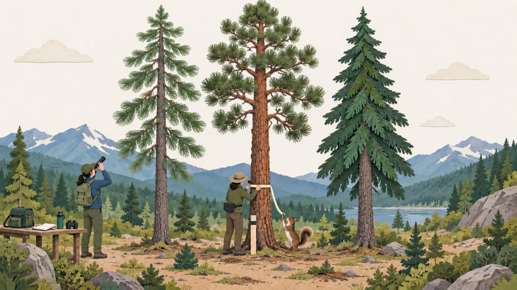

Ilustrační obraz vytvořen AI.

U každého jehličnanu známe

- **druh stromu** — tři severoamerické jehličnany;
- **průměr kmene** ve výšce 1,3 m (cm);
- **výšku stromu** (m).

Mají stejně silné stromy různých druhů stejnou výšku?

## Co si pamatujete z minulé lekce?

Odpovězte samostatně na tři krátké otázky. Na telefonu neuvidíte odpovědi ostatních; společné výsledky otevřeme až po hlasování.

[figure not shown]

[Otevřít dotazník v novém okně](https://pollslive.com/p/l09-opakov-n-p-edchoz-lekce-2026-27-iq22of28)

## Jak odpovídala skupina?

[interactive chart not shown]

[Otevřít výsledky mimo prezentaci](https://pollslive.com/p/l09-opakov-n-p-edchoz-lekce-2026-27-iq22of28?view=results)

## Co ukazují nerovnoběžné přímky modrých krabů?

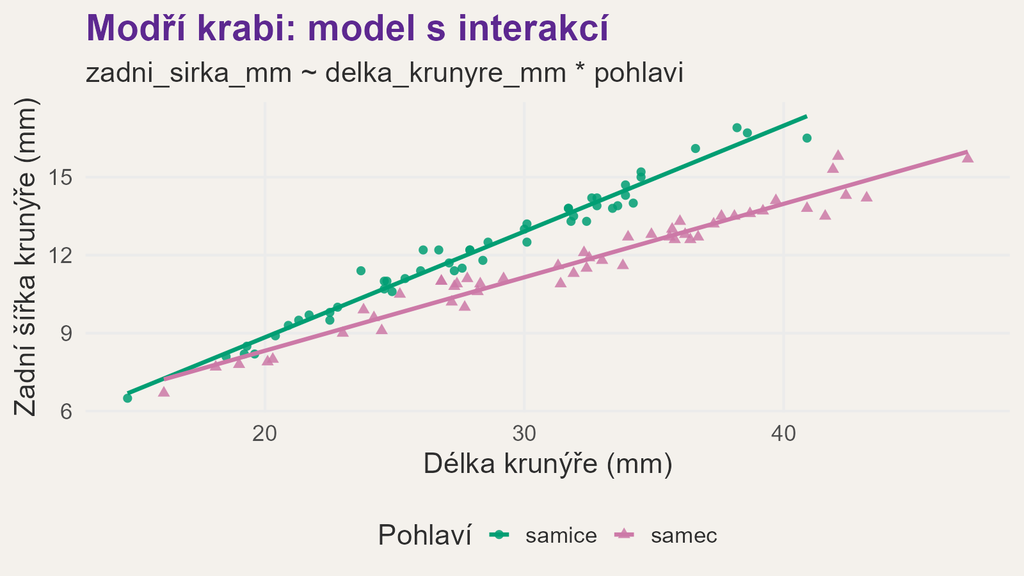

- Rozdíl v zadní šířce krunýře mezi samci a samicemi se mění s délkou krunýře.
- Samci mají při každé délce krunýře o stejný kus užší krunýř než samice.
- O interakci můžeme mluvit, jen když se přímky v grafu překříží.
- Délka krunýře a pohlaví spolu korelují.

Správná odpověď: Rozdíl v zadní šířce krunýře mezi samci a samicemi se mění s délkou krunýře.

Nerovnoběžné přímky znamenají, že rozdíl mezi pohlavími není při všech délkách stejný. Interakce nevyžaduje překřížení přímek a neznamená korelaci prediktorů.

## Co znamená koeficient pohlavisamec v modelu s interakcí?

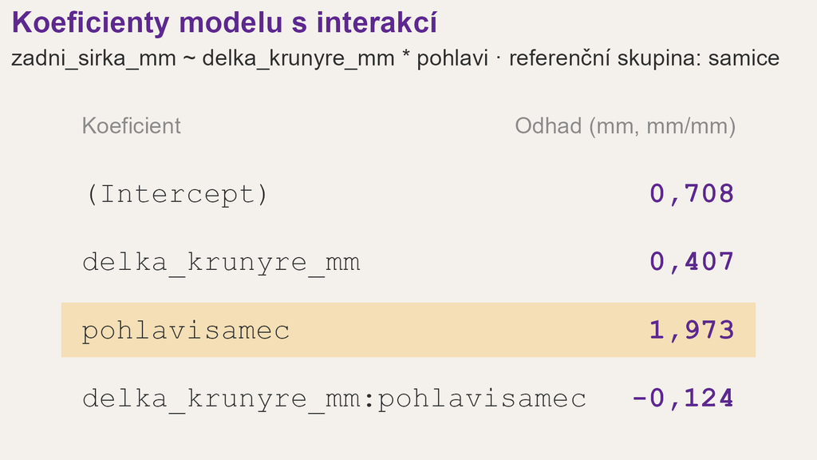

- Rozdíl samec − samice při každé délce krunýře.
- Odhadovaný rozdíl samec − samice při délce krunýře 0 mm.
- Rozdíl samec − samice při průměrné délce krunýře.
- Rozdíl sklonů mezi samci a samicemi.

Správná odpověď: Odhadovaný rozdíl samec − samice při délce krunýře 0 mm.

V modelu s interakcí je koeficient pohlaví podmíněný: porovnává pohlaví tam, kde je délka krunýře rovna nule. Při jiné délce musíme přičíst příspěvek interakčního koeficientu.

## Čím se liší dva kandidátní modely pro modré kraby?

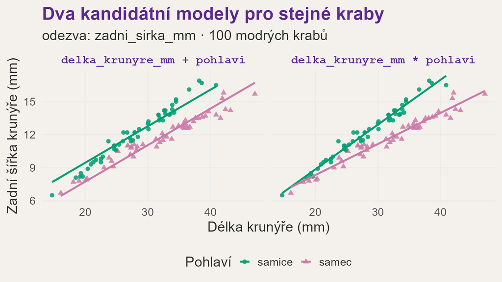

- Aditivní model pohlaví vůbec nezohledňuje.
- Interakční model používá jiné kraby než aditivní model.
- Interakční model předpovídá jinou odezvu než aditivní model.
- Interakční model navíc odhaduje rozdíl sklonů, takže rozdíl mezi pohlavími se může měnit s délkou.

Správná odpověď: Interakční model navíc odhaduje rozdíl sklonů, takže rozdíl mezi pohlavími se může měnit s délkou.

delka_krunyre_mm * pohlavi znamená delka_krunyre_mm + pohlavi + delka_krunyre_mm:pohlavi. Oba modely používají stejné kraby i stejnou odezvu; liší se tím, zda dovolí různé sklony.

## Výsledky učení

Po lekci dokážete:

- vypočítat a vysvětlit R² ze dvou součtů čtverců;
- vysvětlit, proč nejvyšší R² automaticky neznamená nejlepší model;
- interpretovat adjustované R² a použít AIC k porovnání kandidátů;
- sestavit malou sadu biologicky zdůvodněných kandidátních modelů;
- obhájit volbu modelu pomocí otázky, složitosti, diagnostiky a interpretovatelnosti.

# Jedna přímka pro všechny stromy?

## Jeden řádek tabulky představuje jeden strom

```r
data_stromy <- read.csv(
  file = here::here("data", "allometrie_stromu.csv")
)
data_stromy$druh_stromu <- factor(
  x = data_stromy$druh_stromu
)

vec_promenne <- c(
  "druh_stromu", "prumer_kmene_cm", "vyska_stromu_m"
)

head(
  x = data_stromy[, vec_promenne],
  n = 4
)
```

```
            druh_stromu prumer_kmene_cm vyska_stromu_m
1 Pseudotsuga menziesii           54.61          27.04
2 Pseudotsuga menziesii           34.80          27.42
3 Pseudotsuga menziesii           24.89          21.23
4 Pseudotsuga menziesii           28.70          24.96
```

63 stromů

- *Pinus monticola*: 19 stromů
- *Pinus ponderosa*: 22 stromů
- *Pseudotsuga menziesii*: 22 stromů
- chybějící hodnoty: 0
- průměr kmene: 4,8–73,7 cm
- výška: 3,6–45,0 m

Data: J. Marshall, University of Idaho · balíček `lgrdata` 0.1.1 (`allometry`) · CC0

## Jak se výška mění s průměrem kmene?

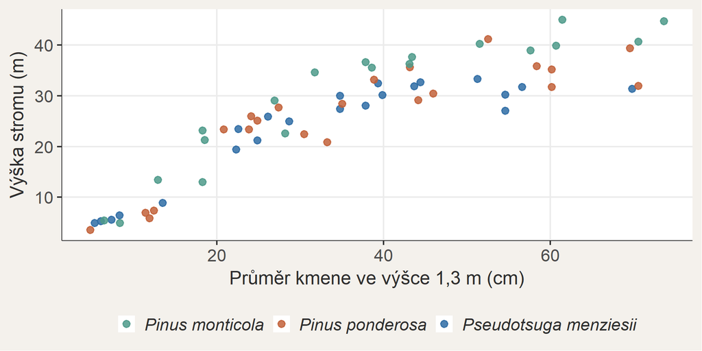

**Ve dvojici:** Jaký vzorec v datech převládá? Co by mohlo vadit jedné přímce pro všechny stromy?

## Jedna společná přímka pro všechny druhy

```r
mod_spolecny <- lm(
  formula = vyska_stromu_m ~
    prumer_kmene_cm,
  data = data_stromy
)

coef(object = mod_spolecny)
```

```
    (Intercept) prumer_kmene_cm
      7.5967386       0.5179077
```

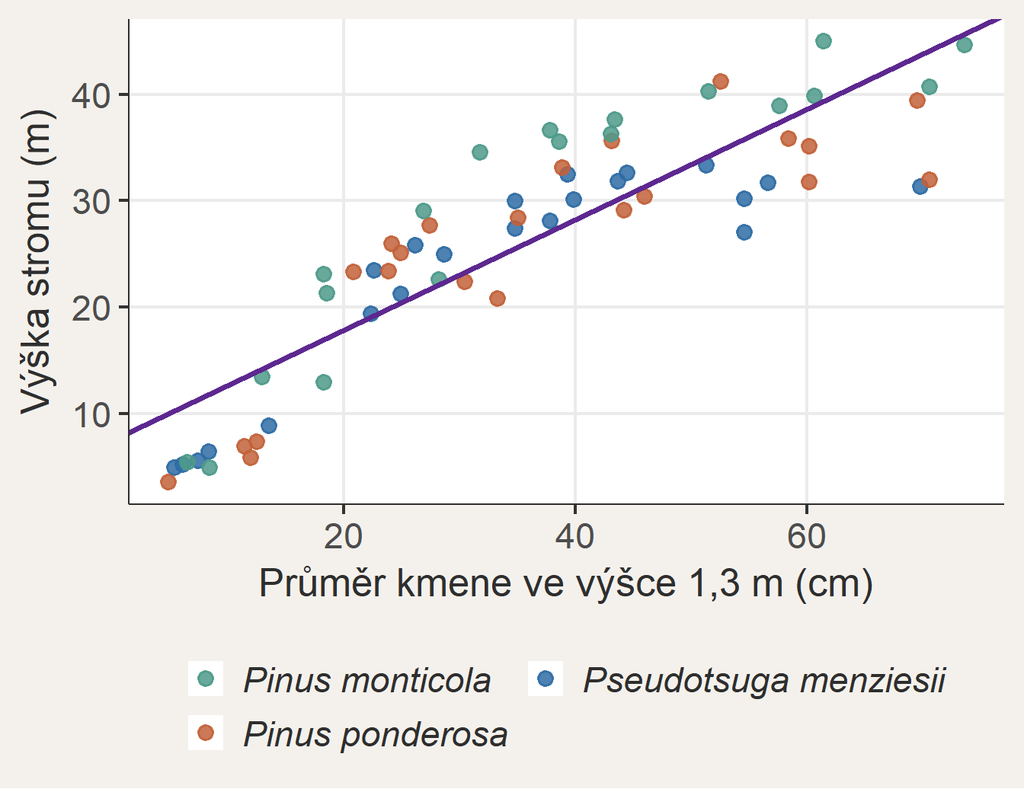

Sklon: o 0,52 m vyšší odhadovaná výška na každý centimetr průměru — stejně pro všechny druhy.

## Co už umíme přečíst ze `summary()`?

```r
summary(object = mod_spolecny)
```

```
Call:
lm(formula = vyska_stromu_m ~ prumer_kmene_cm, data = data_stromy)

Residuals:
     Min       1Q   Median       3Q      Max
-12.4226  -5.3191   0.7425   4.6637  10.5197

Coefficients:
                Estimate Std. Error t value Pr(>|t|)
(Intercept)      7.59674    1.47310   5.157 2.88e-06 ***
prumer_kmene_cm  0.51791    0.03647  14.201  < 2e-16 ***
---
Signif. codes:  0 '***' 0.001 '**' 0.01 '*' 0.05 '.' 0.1 ' ' 1

Residual standard error: 5.548 on 61 degrees of freedom
Multiple R-squared:  0.7678,    Adjusted R-squared:  0.764
F-statistic: 201.7 on 1 and 61 DF,  p-value: < 2.2e-16
```

Známe: volání modelu · residua · koeficienty s nejistotou

## Zůstává v residuích rozdíl mezi druhy?

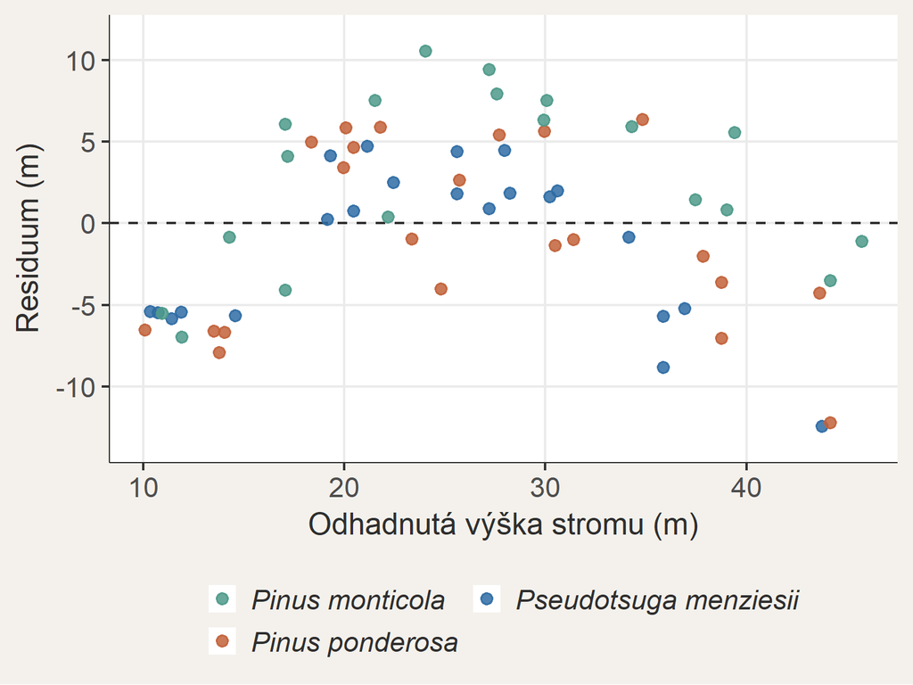

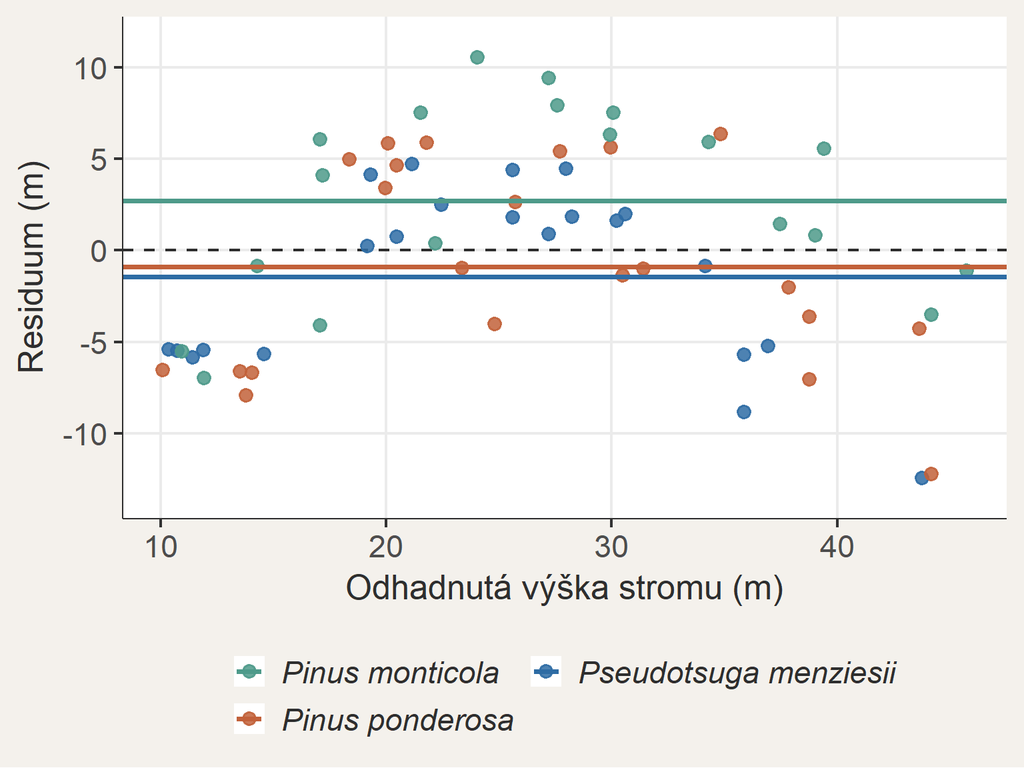

Leží residua některého druhu převážně nad nulou, nebo pod ní?

Průměrné residuum *P. monticola*: +2,7 m

Společná přímka přehlíží rozdíly mezi druhy.

# Tři představy o růstu stromů

## Jaké jiné přímky by mohly stromy popsat?

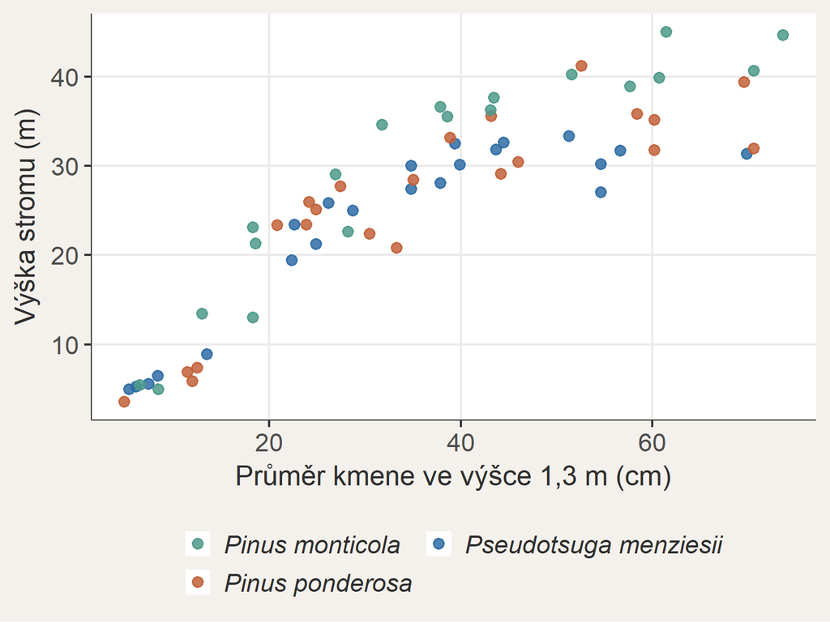

**Ve dvojici:** Načrtněte dvě jiné možnosti než jednu společnou přímku.

Co by každá z nich tvrdila o stromech?

Pomůcka: modely z minulé lekce — `+` a `*`.

## Tři modely vyjadřují tři biologické představy

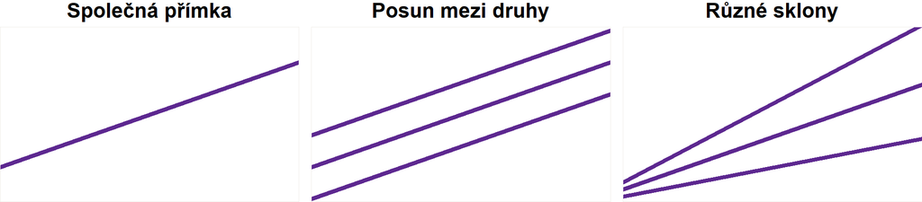

`vyska ~ prumer`

Všechny druhy sdílejí stejný intercept i sklon.

`vyska ~ prumer + druh`

Při stejném průměru se druhy mohou lišit výškou, sklon sdílejí.

`vyska ~ prumer * druh`

Vztah průměru a výšky se může mezi druhy lišit.

Tuto sadu kandidátů určíme předem — z biologické otázky, ne z výsledků.

## Všechny tři modely odhadneme ze stejných 63 stromů

```r
# Společnou přímku odhadneme znovu, aby byly všechny tři modely vedle sebe
mod_spolecny <- lm(
  formula = vyska_stromu_m ~ prumer_kmene_cm,
  data = data_stromy
)

mod_aditivni <- lm(
  formula = vyska_stromu_m ~ prumer_kmene_cm + druh_stromu,
  data = data_stromy
)

mod_interakce <- lm(
  formula = vyska_stromu_m ~ prumer_kmene_cm * druh_stromu,
  data = data_stromy
)
```

Stejná odezva `vyska_stromu_m` · stejných 63 stromů v každém modelu

## Který model prochází nejblíže pozorovaným stromům?

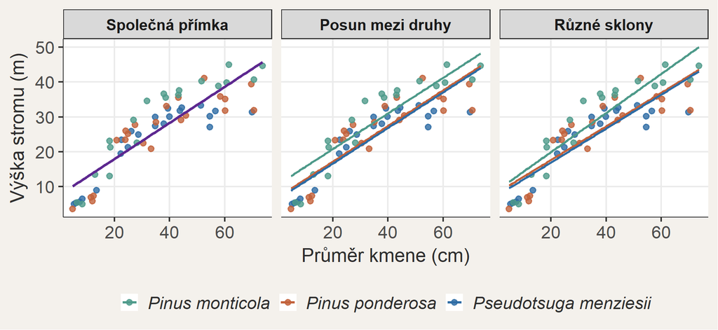

**A** · Společná přímka

**B** · Posun mezi druhy

**C** · Různé sklony

## Nejblíže prochází přímky s různými sklony

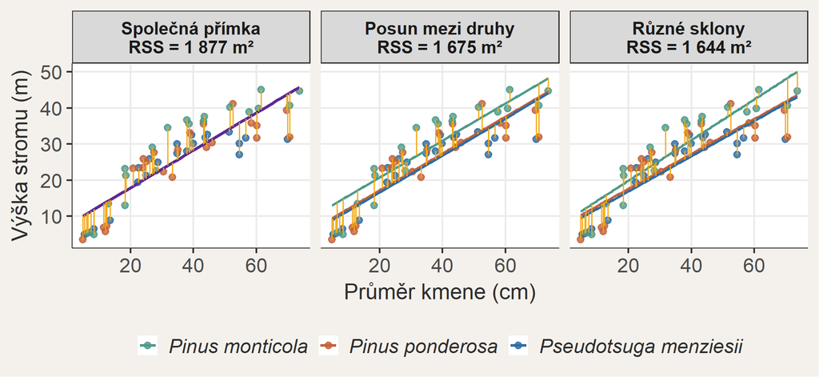

Je proto nejlepší?

## Podle čeho poznáme lepší model?

Podle čeho byste mezi modely vybírali?

- jak těsně model odpovídá pozorovaným datům;
- kolik koeficientů potřebuje;
- zda v residuích nezůstává systematický vzorec;
- zda odpovídá biologické otázce;
- zda jeho výsledek dokážeme smysluplně interpretovat.

Žádné jediné číslo neodpoví na všechny tyto otázky.

# Jak změřit shodu modelu s daty?

## Co už víme o součtu čtverců residuí?

L03

Kandidátní přímky jsme porovnávali součtem čtverců residuí.

L04

Stejnou veličinu jsme označili **RSS** (*residual sum of squares*).

L06

Skupinové průměry RSS zmenšily oproti jednomu společnému průměru.

Co se stane s RSS, když přímka prochází blíže pozorovaným bodům?

Kratší residua → menší čtverce → menší RSS = těsnější shoda s daty.

## Je přímka lepší než předpověď průměrem?

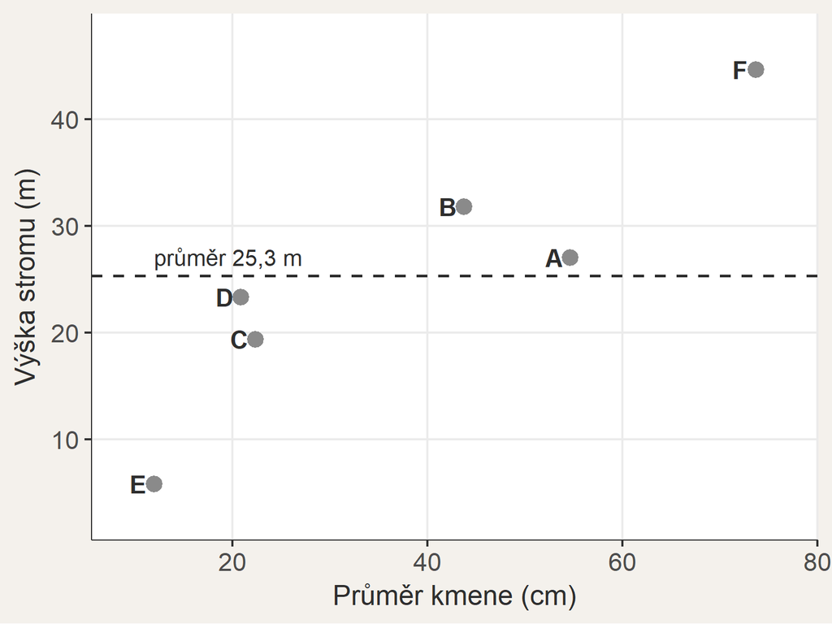

Šest skutečných stromů z tabulky.

Předpověď bez prediktoru: každému stromu průměrnou výšku.

Prošla by přímka podle průměru kmene body blíže než průměr?

## Jak velké jsou rozdíly výšek kolem průměru?

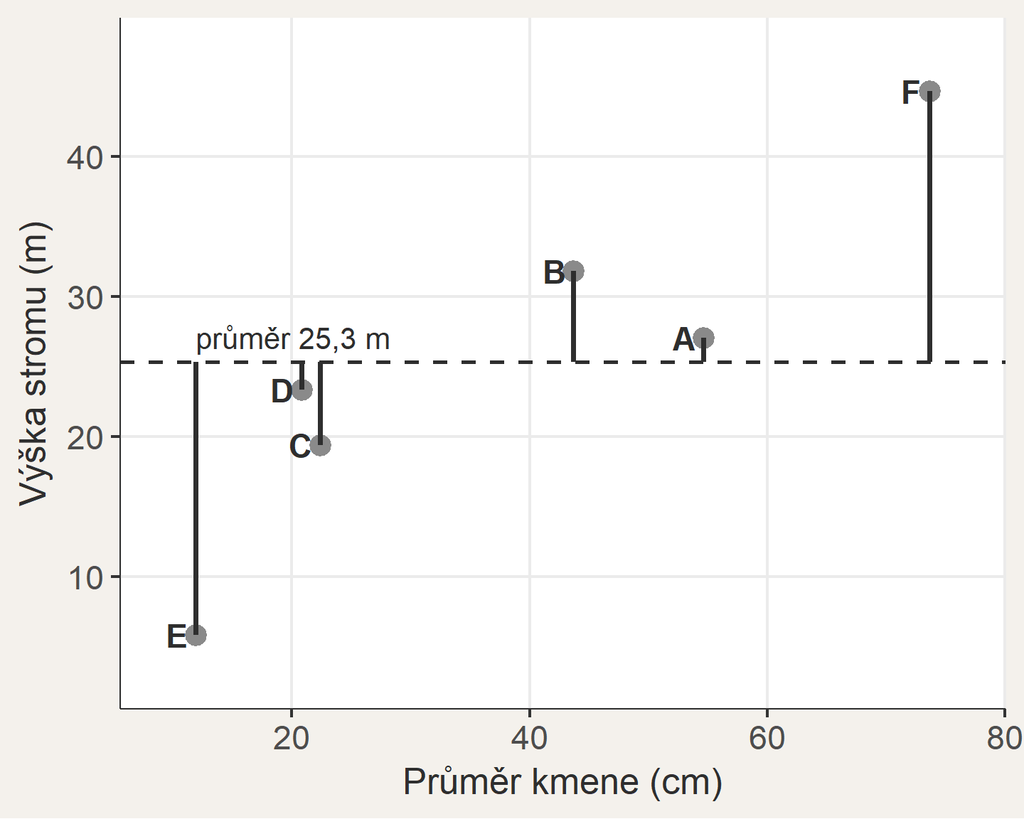

| Strom | Odchylka | Čtverec |
| --- | --- | --- |
| A | 1,7 | 2,9 |
| B | 6,5 | 42,0 |
| C | -6,0 | 35,5 |
| D | -2,0 | 4,0 |
| E | -19,5 | 380,2 |
| F | 19,3 | 372,2 |

Součet čtverců: 836,8 m²

Tomuto součtu říkáme celkový součet čtverců (*total sum of squares*).

## Kolik rozdílů zůstane po odhadnutí přímky?

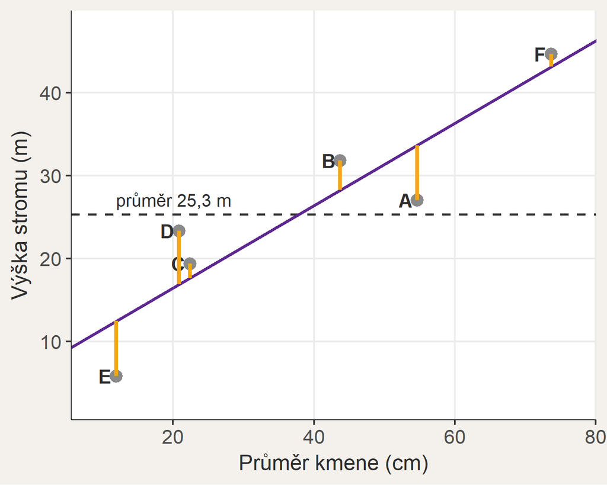

| Strom | Residuum | Čtverec |
| --- | --- | --- |
| A | -6,6 | 43,9 |
| B | 3,6 | 12,8 |
| C | 1,7 | 3,0 |
| D | 6,4 | 41,4 |
| E | -6,6 | 44,1 |
| F | 1,5 | 2,3 |

RSS: 147,6 m² · celkový: 836,8 m²

Který strom leží nejvýše nad přímkou? A který nejvíce přispívá k RSS?

## Jakou část rozdílů přímka zachytila?

$$\text{zachycený podíl} = 1 - \frac{\text{součet čtverců residuí}}{\text{celkový součet čtverců}}$$

Jaká část rozdílů ve výšce zůstala a jakou část přímka zachytila? Dosaďte RSS 147,6 m² a celkový součet čtverců 836,8 m².

$$\text{zachycený podíl} = 1 - \frac{147{,}6}{836{,}8}$$

$$\text{zachycený podíl} = 0{,}824$$

## Zachycený podíl se jmenuje R²

Koeficient determinace R² (*coefficient of determination*)

$$\Large R^2 = 1 - \frac{SS_{\mathrm{res}}}{SS_{\mathrm{total}}}$$

- $SS_{\mathrm{res}}$ — součet čtverců residuí (RSS) od odhadnuté přímky;
- $SS_{\mathrm{total}}$ — celkový součet čtverců odchylek od průměru;
- u šesti stromů: $R^2 = 0{,}824$.

## Jak se mění RSS a R², když přímku natáčíme?

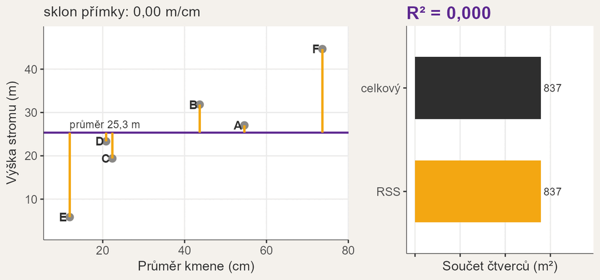

Sledujte oranžové úsečky a sloupec RSS: kdy je R² nulové a kdy největší?

## Stejných šest stromů, čtyři natočení přímky

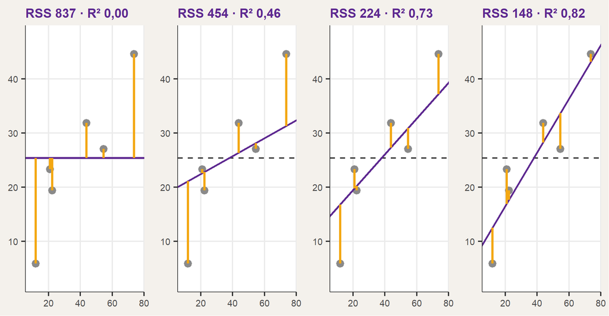

Vodorovná přímka je předpověď průměrem: RSS = celkový součet čtverců, R² = 0. Odhadnutá přímka má nejmenší RSS, a proto největší R².

## Dává `summary()` stejné R² pro všech 63 stromů?

$$R^2 = 1 - \frac{1 877{,}4}{8 084{,}6} = 0{,}768$$

```r
summary(object = mod_spolecny)$r.squared
```

```
[1] 0.7677804
```

`Multiple R-squared` ve výpisu je tentýž výpočet — nic nového.

Společná přímka má R² = 0,768. Co to znamená?

**A**

Model správně předpověděl 76,8 % stromů.

**B**

Model zachytil 76,8 % variability výšky kolem průměru v těchto datech.

**C**

S pravděpodobností 0,768 je model pravdivý.

Přesvědčte souseda, proč jste vybrali svoji možnost.

Obhajitelná je B: R² popisuje podíl zachycené variability v datech, ze kterých byl model odhadnut.

## Co R² popisuje a na co nestačí?

R² popisuje

- podíl variability odezvy zachycený modelem;
- ve stejných datech, na kterých byl model odhadnut.

R² neříká

- zda model splňuje předpoklady;
- zda je vztah příčinný;
- jak dobře model poslouží pro nové stromy;
- zda je to nejlepší z našich kandidátů?

# Pomáhá každý koeficient navíc?

## Co udělá R² po přidání druhu a interakce?

`prumer` → `prumer + druh` → `prumer * druh`

Co se stane s R², když přidáme druh a interakci?

**A** · R² poroste

**B** · R² může klesnout

**C** · R² zůstane stejné

## R² po přidání členů neklesne

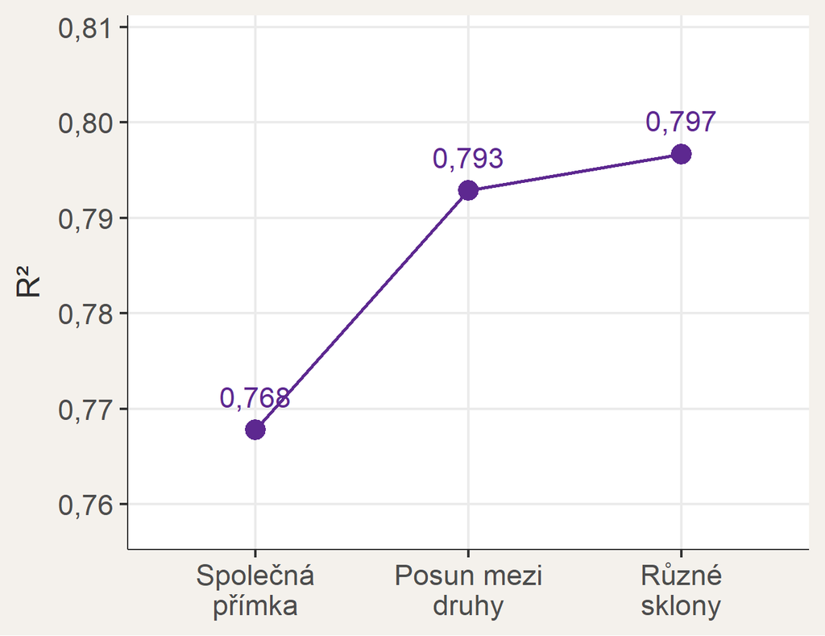

| Model | k | RSS |
| --- | --- | --- |
| Společná přímka | 2 | 1 877 |
| Posun mezi druhy | 4 | 1 675 |
| Různé sklony | 6 | 1 644 |

Složitější model umí zopakovat jednodušší — RSS proto nemůže vzrůst.

**Vyšší R² není automatické vítězství.** I téměř zbytečný prediktor R² nesníží.

## Které koeficienty jednotlivé modely odhadují?

Který seznam patří společné přímce, který posunu mezi druhy a který různým sklonům?

A· Společná přímka · k = 2

`(Intercept)`  
`prumer_kmene_cm`

B· Různé sklony · k = 6

`(Intercept)`  
`prumer_kmene_cm`  
`druh_stromuPinus ponderosa`  
`druh_stromuPseudotsuga menziesii`  
`prumer_kmene_cm:druh_stromuPinus ponderosa`  
`prumer_kmene_cm:druh_stromuPseudotsuga menziesii`

C· Posun mezi druhy · k = 4

`(Intercept)`  
`prumer_kmene_cm`  
`druh_stromuPinus ponderosa`  
`druh_stromuPseudotsuga menziesii`

## Jak R² opravit za počet koeficientů?

$$\text{adjustované R}^2 = 1 - \text{nezachycený podíl} \times \text{úprava za počet stromů a koeficientů}$$

Posun mezi druhy: $R^2 = 0{,}793$, $n = 63$ stromů, $k = 4$ koeficienty

$$R^2_{\mathrm{adj}} = 1 - \left(1 - 0{,}793\right) \times \frac{63 - 1}{63 - 4} = 0{,}782$$

**Adjustované R²** (*adjusted R-squared*):

$$\Large R^2_{\mathrm{adj}} = 1 - \left(1 - R^2\right) \times \frac{n - 1}{n - k}$$

## Co udělá adjustované R² po přidání interakce?

Posun mezi druhy → Různé sklony: R² 0,793 → 0,797 · *k* 4 → 6 · *n* = 63

**A** · adjustované R² vzroste

**B** · adjustované R² klesne

## Adjustované R² po přidání interakce klesne

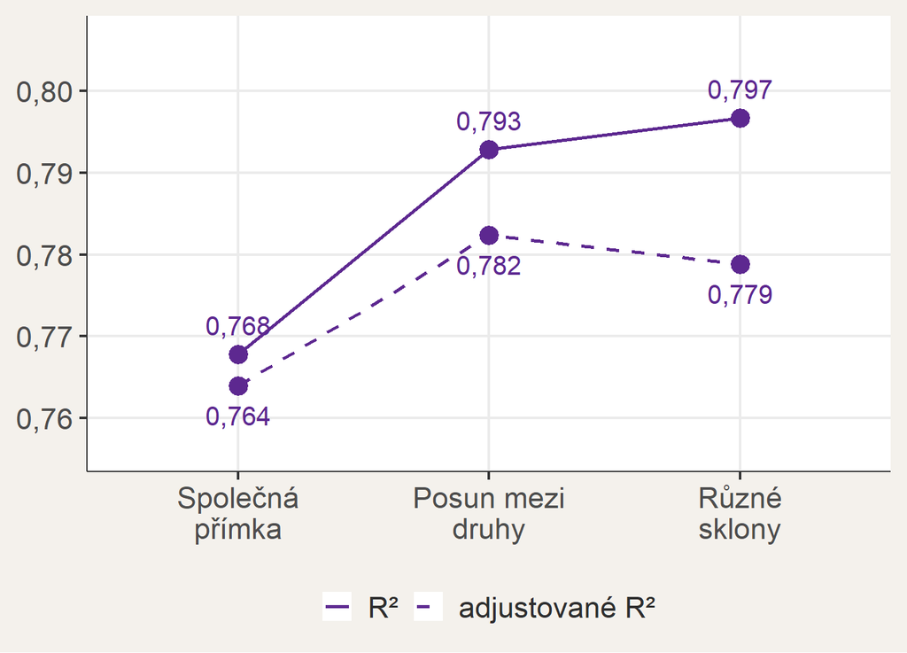

Dva sklony navíc zlepšily R² jen o 0,004.

Zlomek $\frac{n-1}{n-k}$ vzrostl víc, než se zmenšil nezachycený podíl → úprava zvítězila.

## Co už o třech modelech víme?

Jak poznáme, že je model dobrý?

Už umíme říct

- R² měří shodu s daty a vždy upřednostní nejpružnější model.
- Adjustované R² upřednostní posun mezi druhy.

Zatím nevíme

- Kdy se složitost obecně vyplatí?
- Vypadají residua vybraného modelu v pořádku?

# Kdy se složitost vyplatí?

## Vyplatí se model šitý na míru?

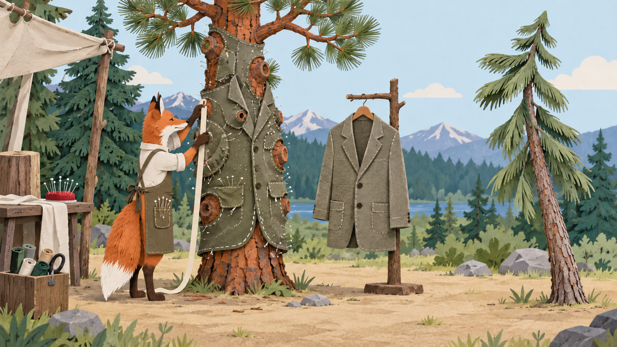

Ilustrační obraz vytvořen AI.

**Ve dvojici:** Posun mezi druhy a různé sklony popisují stromy téměř stejně dobře (R² 0,793 a 0,797). První potřebuje 4 koeficienty, druhý 6.

Který byste upřednostnili? Co byste chtěli vědět, než se rozhodnete?

Princip úspornosti (*parsimony*)

Složitější model upřednostníme jen tehdy, když dostatečně zlepší shodu s daty.

## AIC váží shodu i složitost

Akaikeho informační kritérium (*Akaike information criterion*, AIC)

- lepší shoda AIC snižuje;
- každá odhadovaná veličina navíc AIC zvyšuje;
- preferujeme nižší AIC.

```r
AIC(object = mod_spolecny)
```

```
[1] 398.64
```

AIC není podíl a nemá stejnou škálu jako R².

## Model má AIC 398,64. Je to dobrý model?

**A** · Ano, AIC je nízké.

**B** · Ne, AIC je vysoké.

**C** · Z jedné hodnoty to nepoznáme.

AIC je relativní. Porovnáváme jen modely se stejnou odezvou, stejnými pozorováními a stejným předpokladem o rozdělení residuí.

## O kolik je AIC každého kandidáta vyšší než nejnižší?

$$\Delta\text{AIC} = \text{AIC kandidáta} - \text{nejnižší AIC v sadě}$$

Společná přímka: $398{,}64 - 395{,}44 = 3{,}20$

| Model | AIC | ΔAIC |
| --- | --- | --- |
| Společná přímka | 398,64 | 3,20 |
| Posun mezi druhy | 395,44 | 0,00 |
| Různé sklony | 398,27 | 2,83 |

Posun mezi druhy má ΔAIC = 0 · univerzální práh nepoužíváme

## Ukazují R², adjustované R² a AIC na stejný model?

| Model | k | R² ↑ | adj. R² ↑ | AIC ↓ |
| --- | --- | --- | --- | --- |
| Společná přímka | 2 | 0,768 | 0,764 | 398,64 |
| Posun mezi druhy | 4 | 0,793 | 0,782 | 395,44 |
| Různé sklony | 6 | 0,797 | 0,779 | 398,27 |

**Ve dvojici:** Proč R² upřednostní jiný model než adjustované R² a AIC?

R² hodnotí jen shodu. Adjustované R² a AIC penalizují složitost — dva sklony navíc se nevyplatily. Nejsou to tři hlasy o pravdě.

## Nejlépe podporovaný kandidát nemusí být dobrý model

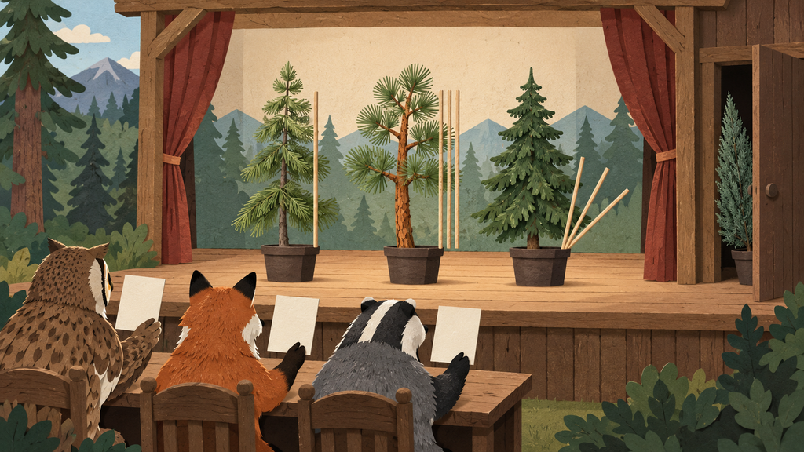

Ilustrační obraz vytvořen AI.

Porovnání řadí jen modely, které jsme do sady zařadili.

Neříká, že je vítěz obecně dobrý. Model, který jsme vůbec neposuzovali, může stromy popsat lépe.

Proto vybraný model ještě zkontrolujeme.

# Obstojí vybraný model?

## Zůstává v residuích modelu s posunem mezi druhy nějaký vzorec?

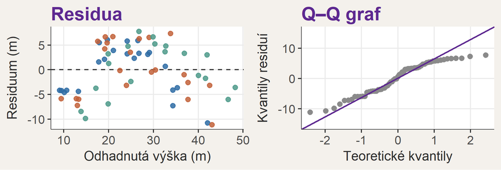

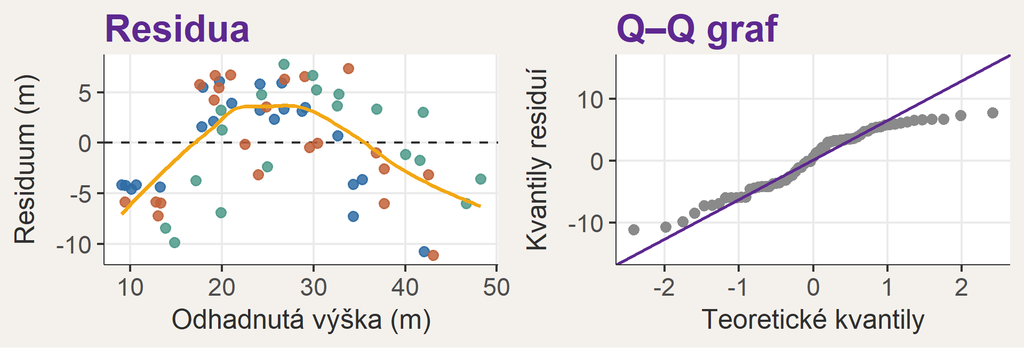

**Ve dvojici:** Leží residua v celém rozsahu odhadnutých výšek náhodně kolem nuly?

Residua tvoří oblouk · Q–Q graf není přímý → závěr formulujeme opatrně.

## Které stromy ovlivňují model nejvíc?

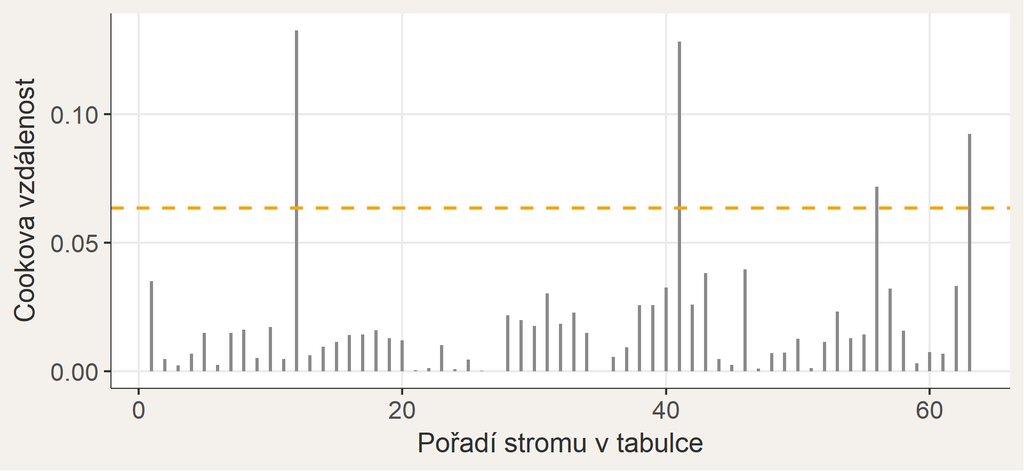

Počet stromů nad orientační čarou $4/n$: 4

Důvod stromy prověřit — ne je automaticky odstranit.

## Obhajte model dvěma větami

40 s sami · ve dvojici porovnejte

„Ze tří kandidátů vybíráme model ____, protože ____.“

„Omezením tohoto závěru je ____.“

Opřete se aspoň o dva různé druhy důkazů: shodu, složitost, diagnostiku, biologický smysl.

## Který model lze pro tyto stromy nejlépe obhájit?

Posun mezi druhy

- zachytí rozdíly mezi druhy, které společná přímka přehlíží;
- nejvyšší adjustované R² (0,782) a nejnižší AIC.

Omezení

- vybírali jsme jen ze tří kandidátů;
- residua tvoří oblouk: přímka nevystihuje tvar vztahu;
- 63 stromů, Q–Q graf není přímý;
- pozorovací data: nejde o příčinný efekt druhu.

Dobrý model nepoznáme podle jediného čísla. Obhajoba propojuje otázku, shodu, složitost, diagnostiku a interpretovatelnost.

## Jak porovnávat modely bez automatického hledání?

1. Položte biologickou otázku.
2. Prohlédněte a zobrazte data.
3. Určete malou sadu zdůvodněných kandidátů.
4. Použijte stejnou odezvu a stejná pozorování.
5. Porovnejte přímky, residua, R², adjustované R² a AIC.
6. Zkontrolujte předpoklady a vlivná pozorování.
7. Obhajte závěr a pojmenujte omezení.

Automatické přidávání a odebírání členů vytvoří mnoho modelů, ale neurčí, které dávají biologický smysl.

## Co si odnést

- Model posuzujeme několika druhy důkazů, ne jedním skóre.
- R² = podíl zachycené variability; po přidání členu neklesne.
- Adjustované R² a AIC penalizují složitost, každé jinak.
- AIC je relativní: jen pro stejnou odezvu a stejná pozorování.
- Kandidáty určujeme předem a závěr obhajujeme i diagnostikou.

Data: J. Marshall, University of Idaho · `lgrdata::allometry` · CC0

## Co když žádná přímka nestačí?

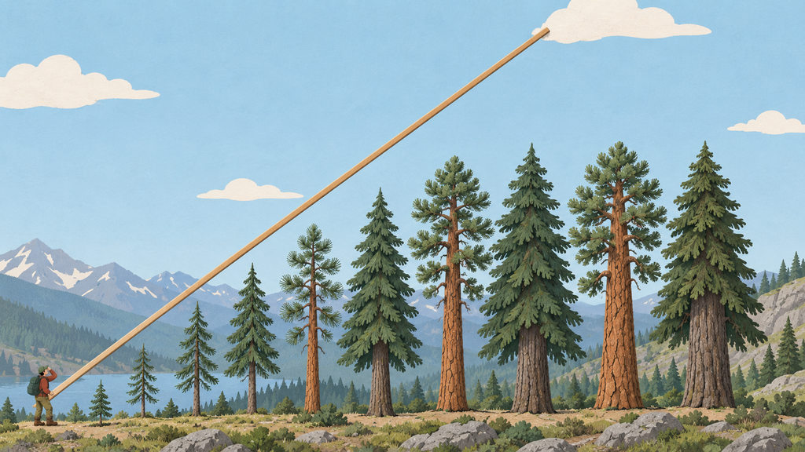

Ilustrační obraz vytvořen AI.

Všechny tři kandidáty jsme kreslili jako přímky — a residua přesto tvoří oblouk.

Jak popsat vztah, který není přímkový?